# PA_1 Template

### Loading packages

```r
library(ggplot2)
library(tidyr)
library(dplyr)
```

### Load the data and (re)set wd

```r
start_dir <- getwd()
setwd("../Reproducible Research Week 2/repdata_data_activity")
files <- list.files()
activity_data <- read.csv2(files[1],
                           sep = ",",
                           header = TRUE,
                           stringsAsFactors = FALSE)
setwd(start_dir)
```

### Prepocessing data

```r
activity_data$date <- as.Date(activity_data$date)
```

# What is mean total number of steps taken per day?

First group data per date to get the total number of steps taken per day:

```r
daily_steps <- activity_data %>%
                group_by(date) %>%
                summarise(steps_per_day = sum(steps, na.rm = TRUE))
```

Plot a histogram of the total number of steps taken each day:

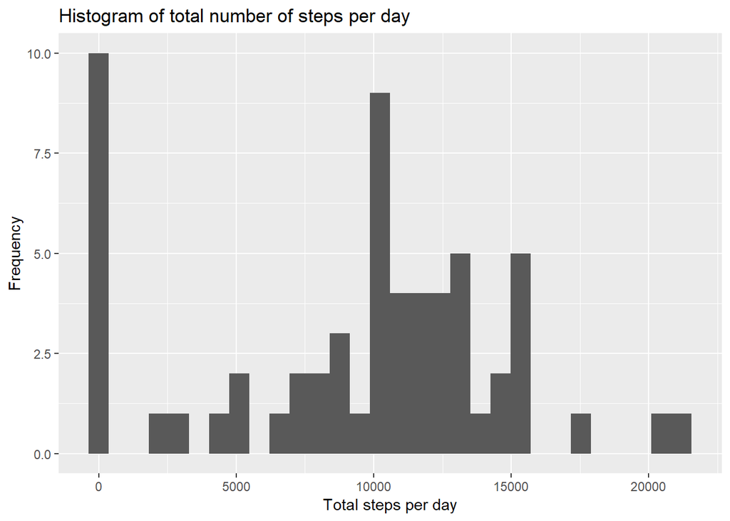

```r
plot_total_steps <- daily_steps %>% ggplot(aes(x = steps_per_day)) +
        geom_histogram() +
        ggtitle("Histogram of total number of steps per day") +
        xlab("Total steps per day") +
        ylab("Frequency")
print(plot_total_steps)
```

Calculate and report the mean and median number of steps taken each day:

```r
mean_steps_day <- mean(daily_steps$steps_per_day, na.rm = TRUE)
median_steps_day <- median(daily_steps$steps_per_day, na.rm = TRUE)
```

Mean of steps taken each day:

```r
print(mean_steps_day)
```

```
## [1] 9354.23
```

Median of steps taken each day:

```r
print(median_steps_day)
```

```
## [1] 10395
```

# What is the average daily activity pattern?

Group data by average amount of steps taken per interval:

```r
avg_steps_interval <- activity_data %>%
        group_by(interval) %>%
        summarise(mean_steps = mean(steps, na.rm = TRUE))
```

Then plot a time series graph to show the daily pattern:

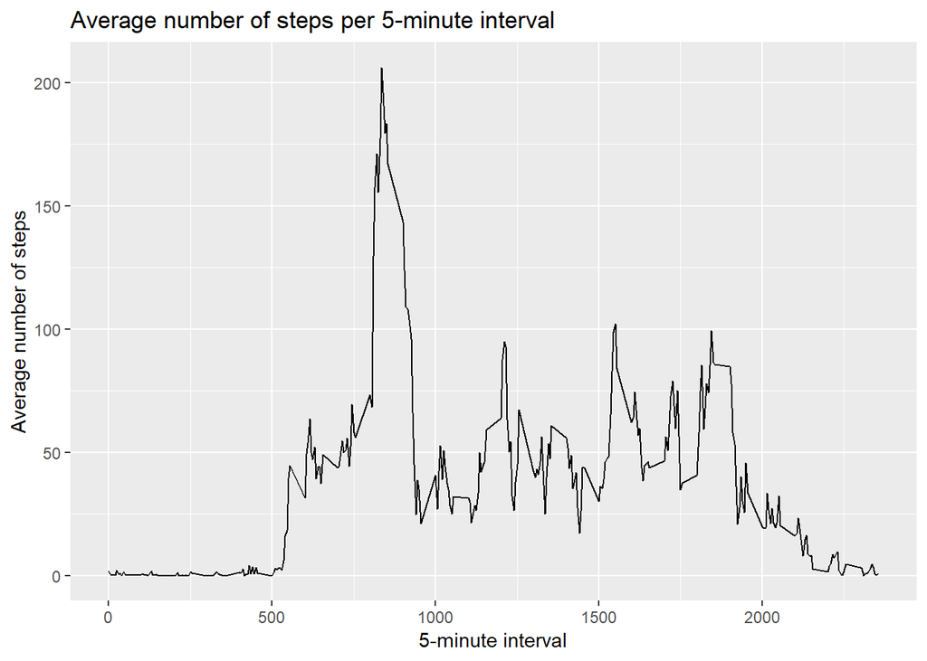

```r
plot_avg_steps_interval <- avg_steps_interval %>%
        ggplot(aes( x = interval, y = mean_steps)) +
        geom_line() +
        ggtitle("Average number of steps per 5-minute interval") +
        xlab("5-minute interval") +
        ylab("Average number of steps")
print(plot_avg_steps_interval)
```

Interval with highest average number of steps:

```r
highest_avg_interval <- avg_steps_interval %>% filter(mean_steps == max(mean_steps, na.rm = TRUE))
print(highest_avg_interval)
```

```
## # A tibble: 1 x 2
##   interval mean_steps
##      <int>      <dbl>
## 1      835       206.
```

# Imputing missing values

Amount of missing values in dataset:

```r
n_na <- sum(is.na(activity_data))
print(n_na)
```

```
## [1] 2304
```

Appearance of NA’s

```r
missing_days <- subset(activity_data, is.na(activity_data$steps))
missing_days <- unique(missing_days$date)
print(missing_days)
```

```
## [1] "2012-10-01" "2012-10-08" "2012-11-01" "2012-11-04" "2012-11-09"
## [6] "2012-11-10" "2012-11-14" "2012-11-30"
```

NA’s occur on 8 specific days. Subject likely forgot to put on the activity tracker. I chose to exclude the missing values from the data. Missing record are removed from the (new) data set:

```r
activity_data_no_na <- subset(activity_data, !is.na(activity_data$steps))
```

Group data without NA’s per date to get the total number of steps taken per day:

```r
daily_steps_no_na <- activity_data_no_na %>%
                        group_by(date) %>%
                        summarise(steps_per_day = sum(steps, na.rm = TRUE))
```

Plot a histogram of total number of steps taken each day after removing missing values:

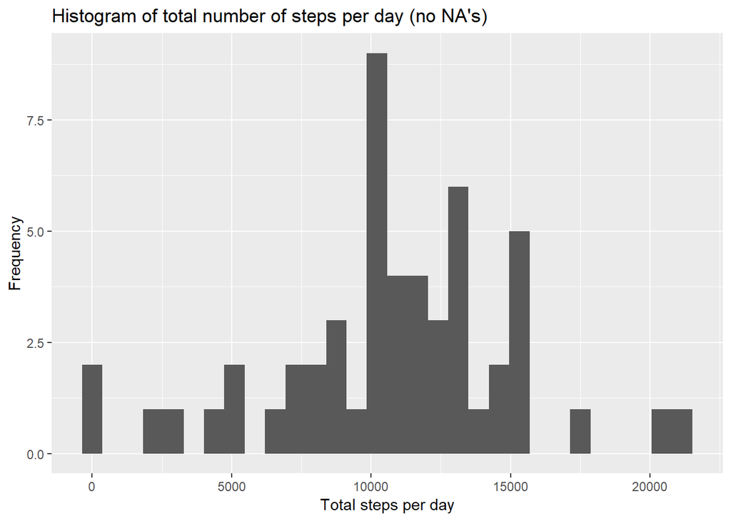

```r
plot_total_steps_no_na <- daily_steps_no_na %>%
        ggplot(aes(x = steps_per_day)) + geom_histogram() +
        ggtitle("Histogram of total number of steps per day (no NA's)") +
        xlab("Total steps per day") +
        ylab("Frequency")
print(plot_total_steps_no_na)
```

Calculate and report the mean and median number of steps taken each day with & without missing values:

```r
mean_steps_no_na <- mean(daily_steps_no_na$steps_per_day, na.rm = TRUE)
median_steps_no_na <- median(daily_steps_no_na$steps_per_day, na.rm = TRUE)
overview <- data.frame(with_na = c(mean_steps_day, median_steps_day),
                       no_na = c(mean_steps_no_na, median_steps_no_na),
                       row.names = c("mean", "median"))
print(overview)
```

```
##         with_na    no_na
## mean    9354.23 10766.19
## median 10395.00 10765.00
```

# Are there differences in activity patterns between weekdays and weekends?

Add variable for type of day of specified date (week- or weekendday) to dataset:

```r
activity_data_no_na$weekday <- weekdays(activity_data_no_na$date)
activity_data_no_na$day_type <- sapply(activity_data_no_na$weekday, function(x) {
        if (x == "zaterdag" | x == "zondag")
                {y <- "weekend"} else
                {y <- "weekday"}
                y
                })
```

Construct a panel plot containing time series plots of the 5-minute intervals and the average number of steps averaged across all weekdays and weekend days:

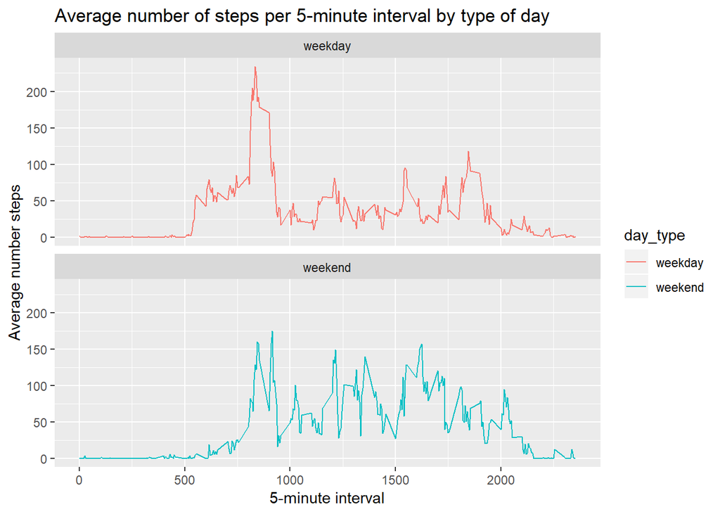

```r
plot_steps_per_interval_type_day <- activity_data_no_na %>%
        group_by(day_type, interval) %>%
        summarise(mean_steps = mean(steps, na.rm = TRUE)) %>%
        ggplot(aes( x = interval, y = mean_steps, color = day_type)) +
        geom_line() +
        ggtitle("Average number of steps per 5-minute interval by type of day") +
        xlab("5-minute interval") +
        ylab("Average number steps") +
        facet_wrap(~day_type, ncol = 1, nrow =2)
print(plot_steps_per_interval_type_day)
```